# Autosomal and Y chromosome STR analysis for forensics

Alexandre Gouy

November 22, 2016

Two datasets are analysed in this study. Individuals from different Swiss populations were genotypes for 21 autosomal microsatellite (first dataset) and 22 Y-STR loci (second dataset).

## 1. Autosomal microsatellite analysis

The dataset consists in 689 indivuduals genotyped for 21 autosomal microsatellite loci. Four subpopulations can be considered (with sample sizes 293, 160, 138 and 98).

Main objectives of this analysis:

- compute basic diversity estimates
- test for Hardy-Weinberg equilibrium
- study population structure
- characterise patterns of linkage disequilibrium (LD) between loci

```r
# Three R packages must be installed to run this analysis
library("adegenet");library("hierfstat");library("pegas")
datpop<-read.genepop("Autosomes.gen",ncode=3)
```

### Allele frequencies and basic summary statistics

First, we can represent the distribution of allele frequencies per locus, overall populations.

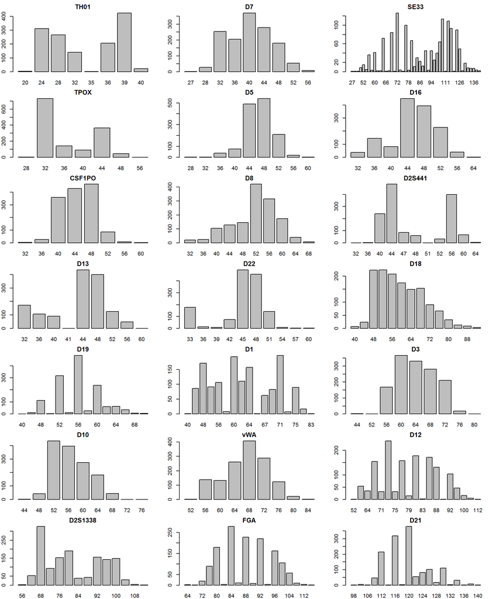

```r
freq<-apply(datpop@tab,2,sum)
nam<-strsplit(names(freq),split="[.]")
loc<-as.factor(unlist(lapply(nam,function(x)x[1])))
alle<-as.numeric(unlist(lapply(nam,function(x)x[2])))

DAT<-data.frame(freq,loc,alle)
DAT<-DAT[order(DAT$alle),]

par(mfrow=c(7,3))
par(mar=c(2,2,2,2))
for(i in unique(DAT$loc)){
  barplot(DAT$freq[DAT$loc==i],names.arg=DAT$alle[DAT$loc==i],main=i)
}
```

Note that given the distribution of frequencies, some loci (e.g. SE33) do not seem to follow a (Generalised) Stepwise Mutation Model. A combined K-allele/SMM could be more appropriate. However, intermediate alleles appear rare and the distributions are relatively smooth of without them.

#### Basic diversity estimates

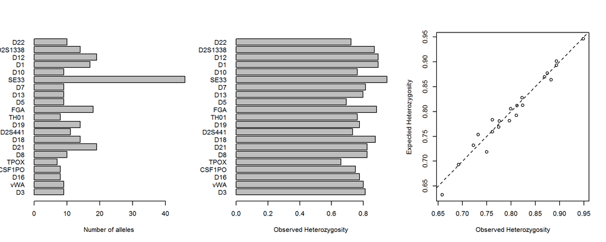

```r
div <- summary(datpop)
par(mfrow=c(1,3))
barplot(div$loc.n.all, xlab="Number of alleles", ylab="",horiz=TRUE,las=1)
barplot(div$Hobs, xlab="Observed Heterozygosity", ylab="",horiz=TRUE,las=1)
plot(div$Hobs, div$Hexp, xlab="Observed Heterozygosity", ylab="Expected Heterozygosity")
abline(0,1,lty=2)
```

We can then generate a table with summary statistics per locus overall populations:

```r
basicstat <- basic.stats(datpop, diploid = TRUE, digits = 4);basicstat
```

```
## $perloc
##             Ho     Hs     Ht     Dst    Htp    Dstp     Fst    Fstp     Fis    Dest
## D3      0.7932 0.7888 0.7901  0.0013 0.7905  0.0017  0.0016  0.0022 -0.0056  0.0082
## vWA     0.7954 0.8068 0.8064 -0.0005 0.8062 -0.0006 -0.0006 -0.0008  0.0142 -0.0033
## D16     0.7778 0.7675 0.7701  0.0026 0.7710  0.0034  0.0033  0.0045 -0.0133  0.0148
## CSF1PO  0.7427 0.7212 0.7207 -0.0005 0.7205 -0.0007 -0.0007 -0.0009 -0.0298 -0.0025
## TPOX    0.6629 0.6408 0.6418  0.0010 0.6421  0.0013  0.0016  0.0021 -0.0345  0.0037
## D8      0.8257 0.8138 0.8132 -0.0006 0.8131 -0.0008 -0.0007 -0.0010 -0.0146 -0.0042
## D21     0.8306 0.8264 0.8265  0.0001 0.8266  0.0001  0.0001  0.0002 -0.0050  0.0007
## D18     0.8735 0.8777 0.8776 -0.0001 0.8776 -0.0002 -0.0001 -0.0002  0.0049 -0.0013
## D2S441  0.7339 0.7559 0.7551 -0.0007 0.7549 -0.0010 -0.0010 -0.0013  0.0290 -0.0040
## D19     0.7802 0.7822 0.7819 -0.0003 0.7819 -0.0003 -0.0003 -0.0004  0.0026 -0.0015
## TH01    0.7654 0.7861 0.7853 -0.0008 0.7850 -0.0011 -0.0011 -0.0014  0.0263 -0.0052
## FGA     0.8835 0.8635 0.8642  0.0007 0.8644  0.0009  0.0008  0.0010 -0.0231  0.0066
## D5      0.6965 0.6944 0.6943 -0.0001 0.6943 -0.0001 -0.0001 -0.0002 -0.0031 -0.0004
## D13     0.7881 0.7765 0.7781  0.0016 0.7786  0.0021  0.0020  0.0027 -0.0148  0.0093
## D7      0.8146 0.8134 0.8138  0.0004 0.8139  0.0005  0.0005  0.0007 -0.0015  0.0029
## SE33    0.9441 0.9446 0.9460  0.0014 0.9465  0.0018  0.0015  0.0019  0.0005  0.0333
## D10     0.7567 0.7586 0.7588  0.0002 0.7588  0.0003  0.0003  0.0004  0.0025  0.0011
## D1      0.8929 0.8998 0.9004  0.0006 0.9006  0.0008  0.0007  0.0009  0.0077  0.0084
## D12     0.8877 0.8935 0.8932 -0.0003 0.8932 -0.0004 -0.0003 -0.0004  0.0065 -0.0033
## D2S1338 0.8671 0.8701 0.8698 -0.0002 0.8698 -0.0003 -0.0003 -0.0004  0.0034 -0.0026
## D22     0.7168 0.7305 0.7299 -0.0006 0.7298 -0.0007 -0.0008 -0.0010  0.0188 -0.0028
##
## $overall
##      Ho      Hs      Ht     Dst     Htp    Dstp     Fst    Fstp     Fis    Dest
##  0.8014  0.8006  0.8008  0.0002  0.8009  0.0003  0.0003  0.0004 -0.0010  0.0017
```

#### Hardy-Weinberg Equilibrium (HWE)

HWE has also been tested:

```r
hw.test(datpop, B = 1000)
```

```
##              chi^2   df Pr(chi^2 >) Pr.exact
## D3        24.64688   36 0.923791749    0.691
## vWA       23.09834   36 0.952724838    0.814
## D16       35.07648   28 0.167651964    0.437
## CSF1PO    20.78247   28 0.834299781    0.460
## TPOX      38.53000   21 0.011163178    0.419
## D8        51.17538   45 0.244179252    0.217
## D21      128.82685  171 0.993125438    0.219
## D18      129.71133   91 0.004815620    0.098
## D2S441    63.88466   55 0.192648091    0.144
## D19       78.37070   91 0.824667236    0.640
## TH01      24.38793   28 0.660903760    0.439
## FGA       87.63467  153 0.999995082    0.946
## D5        16.30150   36 0.998057199    0.930
## D13       48.09884   36 0.085612083    0.465
## D7        24.71001   36 0.922407492    0.843
## SE33    1157.68205 1035 0.004510538    0.848
## D10       23.96953   36 0.937615634    0.461
## D1       123.41849  136 0.772465391    0.278
## D12      389.59888  171 0.000000000    0.364
## D2S1338   69.55534   91 0.953963055    0.763
## D22       29.72817   45 0.961378789    0.495
```

All loci seem to be at HWE considering the exact test with 1000 permutations.

### Linkage disequilibrium analysis

Linkage disequilibrium between pairs of loci has been tested using Arlequin. A few loci appear significantly associated (8 out of 210 combination tested) at a 5% significance level. However, none of them resist to a Bonferroni correction (new threshold is alpha = 0.05/210 = 0.00024).

Furthermore, the p-values seem to be uniformly distributed (confirmed by the KS test):

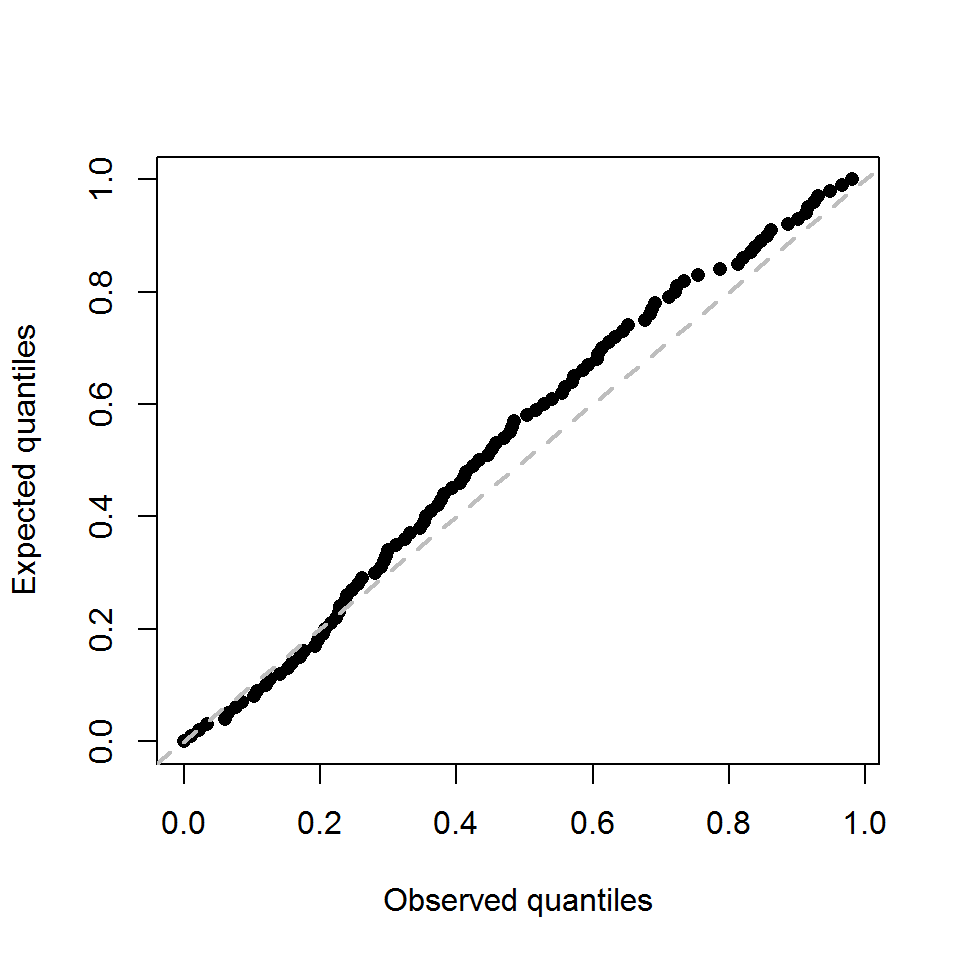

```r
pv<-c(0.59355,0.19735,0.35414,0.25247,0.45988,0.07924,0.64979,0.41351,0.20622,0.23641,0.67742,0.20691,0.67692,0.25278,0.55424,0.05999,0.02118,0.39364,0.10111,0.60636,0.28196,0.68454,0.93301,0.14104,0.59918,0.29071,0.9137,0.04524,0.84677,0.4815,0.37258,0.2386,0.35321,0.57262,0.80765,0.62798,0.22747,0.22397,0.29659,0.42332,0.55649,0.6083,0.16298,0.15354,0.42688,0.55824,0.14079,0.32627,0.62273,0.48175,0.47138,0.87545,0.29303,0.85583,0.40514,0.38001,0.29871,0.06893,0.22097,0.45419,0.73841,0.25972,0.36652,0.91314,0.24053,0.65092,0.48881,0.92495,0.3244,0.81965,0.60911,0.7241,0.47988,0.83602,0.46475,0.91645,0.01106,0.41051,0.21572,0.95007,0.00025,0.85777,0.3817,0.73097,0.33396,0.25841,0.76522,0.35589,0.72247,0.98069,0.07318,0.10574,0.96994,0.85827,0.37245,0.34383,0.5035,0.56337,0.40645,0.57118,0.10836,0.80477,0.71166,0.90151,0.23772,0.54018,0.19604,0.92488,0.58574,0.60705,0.06199,0.82096,0.17642,0.61342,0.96257,0.8224,0.44057,0.12086,0.02593,0.23491,0.1033,0.74922,0.31771,0.41445,0.22741,0.22435,0.48488,0.18929,0.70722,0.81615,0.83521,0.48281,0.14261,0.29409,0.90182,0.92376,0.38264,0.16967,0.17635,0.17298,0.4715,0.28646,0.93757,0.63655,0.69085,0.39489,0.20072,0.45301,0.65142,0.43063,0.45194,0.2999,0.35733,0.12267,0.44969,0.0295,0.63292,0.58943,0.52093,0.71972,0.91526,0.15679,0.19779,0.68691,0.5848,0.00594,0.21654,0.22891,0.84858,0.37427,0.4352,0.11674,0.08586,0.88983,0.20654,0.56049,0.24359,0.06274,0.96588,0.53975,0.12692,0.88576,0.57362,0.71216,0.29665,0.68679,0.50687,0.83921,0.27628,0.15242,0.51769,0.33208,0.51781,0.01225,0.26278,0.7236,0.31021,0.35039,0.69185,0.84602,0.30671,0.35189,0.41595,0.08624,0.63286,0.75984,0.54212,0.61611,0.37752,0.68173)

qqplot(pv,qunif(seq(0,1,0.01)),pch=16,xlab="Observed quantiles",ylab="Expected quantiles")
abline(0,1,lty=2,lwd=2,col="grey")
```

```r
ks.test(pv,"punif")
```

```
##
##  One-sample Kolmogorov-Smirnov test
##
## data:  pv
## D = 0.092021, p-value = 0.05707
## alternative hypothesis: two-sided
```

### Conclusion

These autosomal microsatellite appear to be compatible with classical microsatellite mutation models. They present a high intra-individual diversity (could be confirmed by running an AMOVA), and the population structure seems really low in Switzerland. They appear appropriate for forensics analysis.

## 2. Y-chromosome microsatellite analysis

The dataset consists in 481 male indivuduals genotyped for 22 STR loci located on the Y chromosome.

Main objectives of this analysis:

- compute basic diversity estimates
- characterise patterns of linkage disequilibrium (LD) between loci
- study population structure using multivariate analysis

```r
# Three R packages must be installed to run this analysis
library("adegenet");library("hierfstat");library("pegas")

# data preparation
dat<-read.table("Ychrom.txt",header=TRUE,sep="\t",colClasses="character")
rownames(dat)<-dat$ind
dat2<-df2genind(dat[,-1:-2],ncode=2);pop(dat2)<-dat$pop

# information about the samples
samples<-read.table("samples.txt",sep="\t",header=TRUE)
rownames(samples)<-samples$id
SAMP<-samples[dat$ind,]
```

### Allele frequencies and basic summary statistics

First, we can represent the distribution of allele frequencies per locus, overall populations.

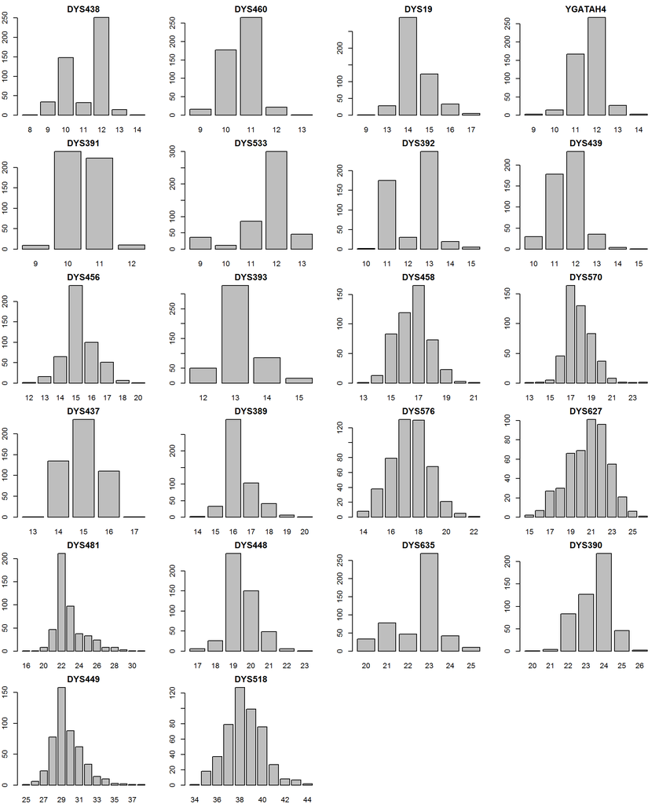

```r
freq<-apply(dat2@tab,2,sum)
nam<-strsplit(names(freq),split="[.]")
loc<-as.factor(unlist(lapply(nam,function(x)x[1])))
alle<-as.numeric(unlist(lapply(nam,function(x)x[2])))

DAT<-data.frame(freq,loc,alle)
DAT<-DAT[order(DAT$alle),]

par(mfrow=c(6,4))
par(mar=c(2,2,2,2))
for(i in unique(DAT$loc)){
  barplot(DAT$freq[DAT$loc==i],names.arg=DAT$alle[DAT$loc==i],
          main=i)
}
```

The distribution of allele frequencies is unimodal most of the time, in agreement with microsatellite mutation models such as SMM/GSM.

A notable exception concerns the two loci DYS438 and DYS392 which present a bimodal distribution. This is the case in most European populations but not in Asia and Africa. The two loci are physically linked and present strong LD patterns.

### Genetic diversity

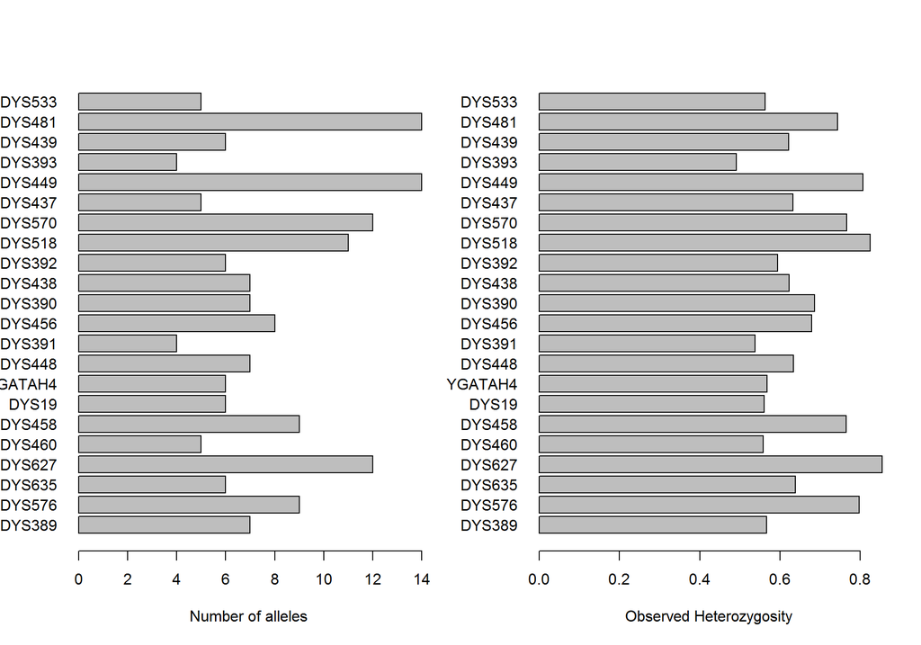

```r
div <- summary(dat2)
par(mfrow=c(1,2))
barplot(div$loc.n.all, xlab="Number of alleles", ylab="",horiz=TRUE,las=1)
barplot(div$Hexp, xlab="Observed Heterozygosity", ylab="",horiz=TRUE,las=1)
```

We can then generate a table with summary statistics per locus overall populations:

```r
basicstat <- basic.stats(dat2, diploid = FALSE, digits = 4);basicstat
```

```
## $perloc
##         Ho     Hs     Ht     Dst    Htp    Dstp     Fst    Fstp Fis    Dest
## DYS389  NA 0.5498 0.5517  0.0019 0.5522  0.0024  0.0034  0.0043  NA  0.0053
## DYS576  NA 0.7964 0.7954 -0.0010 0.7951 -0.0013 -0.0013 -0.0016  NA -0.0064
## DYS635  NA 0.6251 0.6260  0.0009 0.6263  0.0012  0.0015  0.0019  NA  0.0032
## DYS627  NA 0.8549 0.8556  0.0007 0.8557  0.0008  0.0008  0.0010  NA  0.0056
## DYS460  NA 0.5491 0.5501  0.0010 0.5503  0.0012  0.0018  0.0022  NA  0.0027
## DYS458  NA 0.7661 0.7685  0.0024 0.7691  0.0030  0.0031  0.0039  NA  0.0127
## DYS19   NA 0.5555 0.5564  0.0009 0.5566  0.0011  0.0016  0.0020  NA  0.0025
## YGATAH4 NA 0.5680 0.5673 -0.0007 0.5672 -0.0008 -0.0012 -0.0015  NA -0.0019
## DYS448  NA 0.6391 0.6441  0.0050 0.6453  0.0062  0.0077  0.0097  NA  0.0173
## DYS391  NA 0.5331 0.5386  0.0055 0.5400  0.0069  0.0103  0.0128  NA  0.0148
## DYS456  NA 0.6843 0.6889  0.0046 0.6900  0.0057  0.0066  0.0083  NA  0.0181
## DYS390  NA 0.6739 0.6781  0.0041 0.6791  0.0052  0.0061  0.0076  NA  0.0158
## DYS438  NA 0.6074 0.6174  0.0100 0.6199  0.0125  0.0162  0.0201  NA  0.0318
## DYS392  NA 0.5744 0.5808  0.0064 0.5824  0.0079  0.0109  0.0136  NA  0.0187
## DYS518  NA 0.8221 0.8268  0.0047 0.8280  0.0059  0.0057  0.0071  NA  0.0330
## DYS570  NA 0.7543 0.7580  0.0038 0.7590  0.0047  0.0050  0.0062  NA  0.0193
## DYS437  NA 0.6298 0.6294 -0.0004 0.6293 -0.0005 -0.0006 -0.0007  NA -0.0012
## DYS449  NA 0.8011 0.8035  0.0024 0.8041  0.0030  0.0030  0.0037  NA  0.0150
## DYS393  NA 0.4942 0.4933 -0.0009 0.4931 -0.0011 -0.0017 -0.0022  NA -0.0021
## DYS439  NA 0.6124 0.6183  0.0059 0.6197  0.0073  0.0095  0.0118  NA  0.0189
## DYS481  NA 0.7251 0.7297  0.0046 0.7308  0.0057  0.0063  0.0078  NA  0.0208
## DYS533  NA 0.5517 0.5537  0.0020 0.5542  0.0025  0.0036  0.0044  NA  0.0055
##
## $overall
##     Ho     Hs     Ht    Dst    Htp   Dstp    Fst   Fstp    Fis   Dest
##     NA 0.6531     NA     NA     NA     NA     NA     NA     NA     NA
```

### Linkage disequilibrium

We compute a measure of linkage disequilibrium between all pairs of loci:

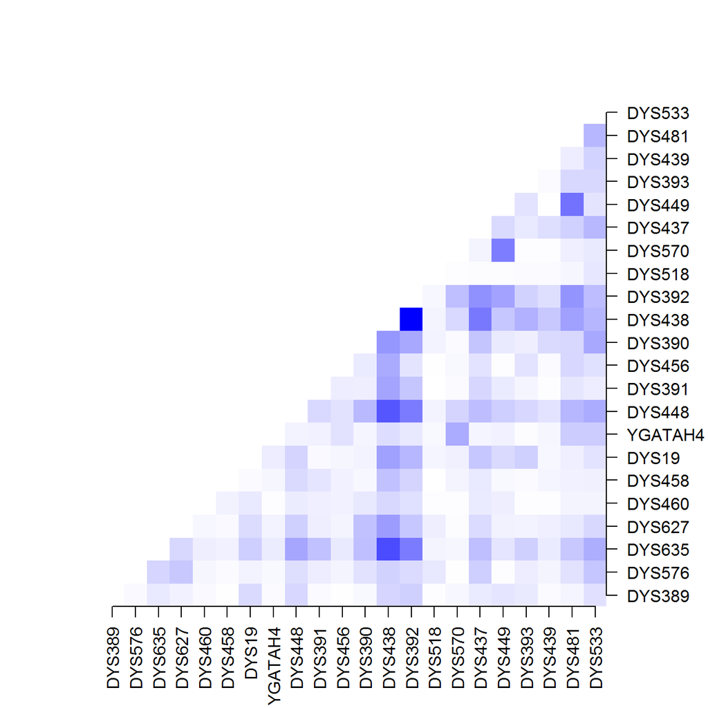

```r
X<-as.loci(dat2)
matLD<-matrix(NA,nrow=22,ncol=22)
rownames(matLD)<-colnames(matLD)<-names(dat2@all.names)
for(i in 1:22){
  for(j in 1:22){
    if(i!=j)matLD[i,j]<-LD(X,locus=c(i,j))$T2[3]
  }
}
matLD<--1*log10(matLD)
diag(matLD)<-NA
matLD[lower.tri(matLD)] <- NA

par(mar=c(5,5,5,5))
col<-rgb(0,0,1,alpha=seq(0,1,0.001))
image(t(matLD),col = col,frame=F,xaxt="n",yaxt="n")
axis(1,at=seq(0,1,length.out=ncol(matLD)),labels=colnames(matLD),las=2)
axis(4,at=seq(0,1,length.out=nrow(matLD)),labels=rownames(matLD),las=2)
```

### Multivariate analysis

We can run a PCA (Principal Component Analysis) on our dataset.

```r
library(ade4)
library(rgl)
library(knitr)
knit_hooks$set(webgl = hook_webgl)

FREQ<-makefreq(dat2)
```

```
##
##  Finding allelic frequencies from a genpop object...
##
## ...done.
```

```r
pcaY<-dudi.pca(FREQ, nf = 3, scannf = FALSE)
```

Then we plot the results, by projecting individuals on axis 1 and 2 (first plot) as well as on axis 1 and 3 (second plot). The groups correspond to the mother tongue: german (d), italian (i) of french (f).

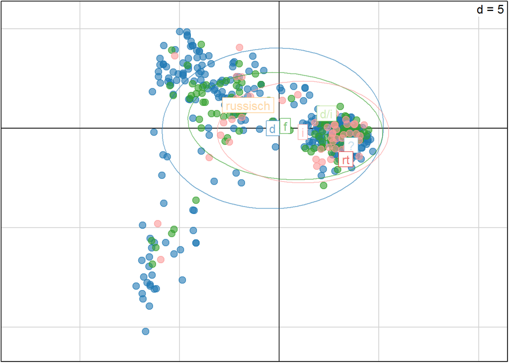

```r
s.class(pcaY$li, fac=as.factor(SAMP$mother.tongue),
        col=transp(funky(12),.6),
        axesel=FALSE, cstar=0, cpoint=2,xax=1,yax=2)
```

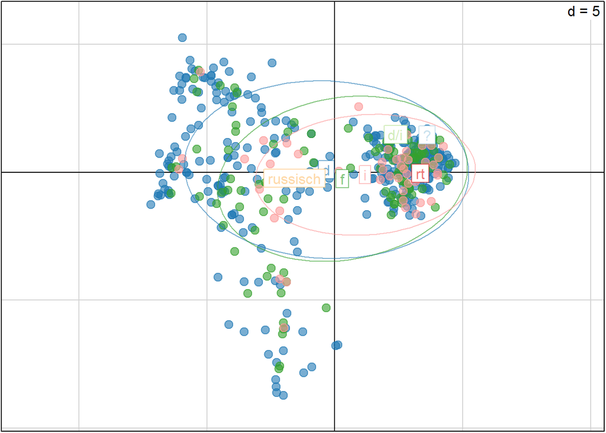

```r
s.class(pcaY$li, fac=as.factor(SAMP$mother.tongue),
        col=transp(funky(12),.6),
        axesel=FALSE, cstar=0, cpoint=2,xax=1,yax=3)
```

We can also cluster the individuals by regions (groups of cantons):

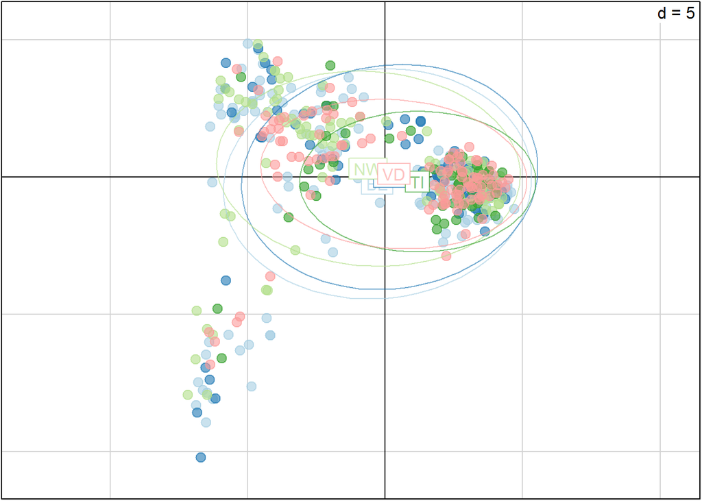

```r
s.class(pcaY$li, fac=as.factor(SAMP$Group),
        col=transp(funky(12),.6),
        axesel=FALSE, cstar=0, cpoint=2,xax=1,yax=2)
```

This time, clustered by canton:

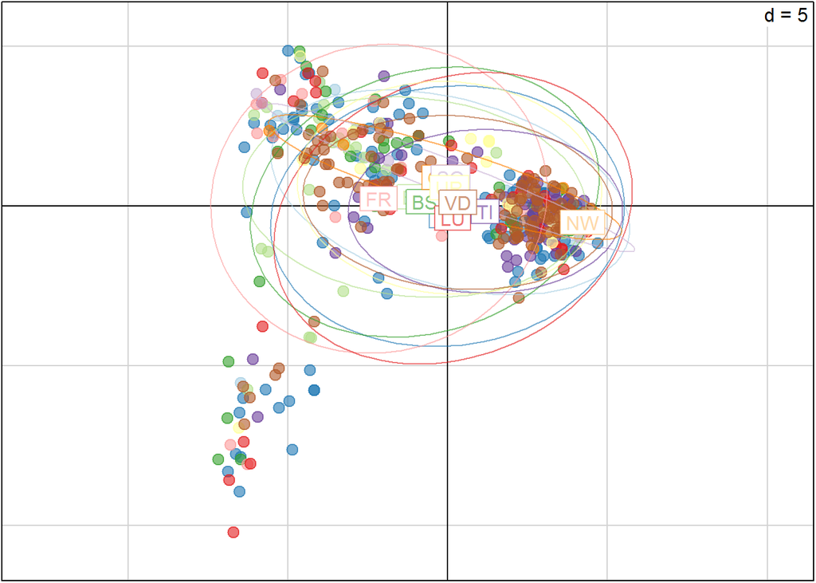

```r
s.class(pcaY$li, fac=as.factor(SAMP$Canton),
        col=transp(funky(12),.6),
        axesel=FALSE, cstar=0, cpoint=2,xax=1,yax=2)
```

Finally, a 3D representation of individuals coordinates on the first 3 axis is possible (interactive plot):

```r
cl<-SAMP$Group
couleur <- as.character(factor(cl,labels=funky(length(unique(cl)))))
with(pcaY$li,plot3d(Axis1,Axis3,Axis2,size=5,col=couleur,type="p",pch=16))
```

[interactive chart not shown]

We can also examine the contribution of the different alleles to this PCA:

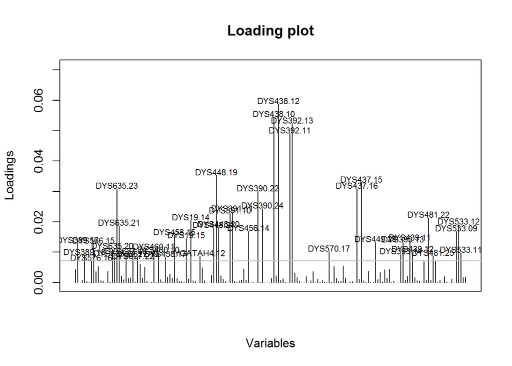

```r
loadingplot(pcaY$c1^2)
```

Alleles explaining most of the variance are found in a relatively small number of loci. Furthermore, most of these loci present the strongest patterns of LD (see above). Two alleles per locus explain most of the variance (e.g. DYS438 10 and 12; DYS392 11 and 13), suggesting that two major haplotypes segregate in Switzerland.

This suggests that the structure we observe in these data is likely to be more ancient than the separation of Swiss populations.

### Conclusion, perspectives

Furthermore, the weak population structure observe in PCA projections can be an atifact. Indeed, it has been shown that uneven sampling has a strong influence on PCA projections (McVean, 2009).

Concerning lower-scale population structure, we observe more genetic differentiation for Y-chromosome loci than for autosomal STRs. However, population structure remains weak. To discriminate between Swiss populations, one would need to get more markers.

To do:

- Haplotype analysis: number of different haplotypes / number of individual to characterise the individuality
- AMOVA: most variance within populations/individuals
- MDS
- haplogroup inference